# Practical C

Gerko Vink

Statistical Programming with R

# Exercises

Begin this practical exercise by setting the maximum line length in `R-Studio` to 80 characters. Go to `RStudio`’s `Preferences` (or `Global Options` under `Tools`) –> `Code` –> `Display`, and tick the `show margin` box. Make sure that the `margin column` is set to `80`

## Exercise 1-5

1. **Install package `mice`.**

Go to `Tools` > `Install Packages` in `RStudio`. If you are connected to the internet, select `Repository` under `Install From` and type `mice` under `Packages`. Leave the `Install to Library` at default and make sure that `Install Dependencies` is selected. Click install. If you are not connected to the internet, select `Package Archive File` under “Install from” and navigate to the respective file on your drive.

Some packages depend on other packages, meaning that their functionality may be limited if their dependencies are not installed. Installing dependencies is therefor recommended, but internet connectivity is required.

If all is right, you will receive a message in the console that the package has been installed (as well as its dependencies).

ALternatively, if you know the name of the package you would like to install - in this case `mice` - you can also call `install.packages("mice")` in the console window.

2. **Load package `mice`.** Loading packages can be done through functions `library()` and `require()`.

```r
library(mice)
```

If you use `require()` within a function, and the required package is not available, `require()` will yield a warning and the remainder of the function is still executed, whereas `library()` will yield an error and terminate all executions. The use of `library()` when not doing too complicated things is preferred - `require()` would result in more computational overhead because it calls `library()` itself.

3. **Most packages have datasets included. Open the `mammalsleep` dataset from package `mice` by typing `mammalsleep` in the console, and subsequently by using the function `View()`.**

Using `View()` is preferred for inspecting datasets that are large. `View()` opens the dataset in a spreadsheet-like window (conform MS Excel, or SPSS). If you `View()` your own datasets, you can even edit the datasets’ contents.

4. **Write the mammalsleep dataset from package `mice` to the work directory (= the directory of your R project) as a tab-delimited text file with `.` as a decimal separator. Use the function `write.table()` and name the file `mammalsleep.txt`.**

```r
library(mice)
write.table(mammalsleep, "mammalsleep.txt", sep = "\t", dec = ".", row.names = FALSE)
```

The command `sep = "\t"` indicates that the file is tabulated and the command `dec = "."` indicates that a point is used as the decimal separator (instead of a comma). `row.names = FALSE` tells `R` that row names are not to be included in the exported file.

5. **Import the `mammalsleep.txt` file with `read.table()`.**

```r
sleepdata <- read.table("mammalsleep.txt", sep = "\t", dec = ".", header = TRUE, stringsAsFactors = TRUE)
```

The command `sep = "\t"` indicates that the file is tabulated and the command `dec = "."` indicates that a point is used as the decimal separator (instead of a comma). `header = TRUE` tells `R` that variable names are included in the header.

All files that are presented in the work directory of the current `R` project, can essentially be imported into the workspace (the space that contains all environments) directly. All other locations require you to specify the specific path from the root of your machine. To find out what the current work directory is, you can type `getwd()` and to change the work directory you can use `setwd()`. The beauty of using projects in RStudio is that you would never have to change the work directory, as the work directory is automatically set, relative to your projects’ `R`-scripts.

There are many packages that facilitate importing data sets from other statistical software packages, such as SPSS (e.g. function `read_spss` from package `haven`), Mplus (package `MplusAutomation`), Stata (`read.dta()` in `foreign`), SAS (`sasxport.get()` from package `Hmisc`) and from spreadsheet software, such as MS Excel (function `read.xlsx()` from package `xlsx`). For a short guideline to import multiple formats into `R`, see e.g. http://www.statmethods.net/input/importingdata.html.

## Exercise 6-10

6. **The dataset we’ve just imported contains the sleepdata by Allison & Cicchetti (1976). Inspect the sleepdata and make yourself familiar with it.**

If you would like to know more about this dataset, you can open the help for the `mammalsleep` dataset in package `mice` through `?mammalsleep`.

Inspecting the sleepdata could be done by

```r
#the data structure
summary(sleepdata) #distributional summaries
```

```
##                       species         bw                brw
##  African elephant         : 1   Min.   :   0.005   Min.   :   0.14
##  African giant pouched rat: 1   1st Qu.:   0.600   1st Qu.:   4.25
##  Arctic Fox               : 1   Median :   3.342   Median :  17.25
##  Arctic ground squirrel   : 1   Mean   : 198.790   Mean   : 283.13
##  Asian elephant           : 1   3rd Qu.:  48.202   3rd Qu.: 166.00
##  Baboon                   : 1   Max.   :6654.000   Max.   :5712.00
##  (Other)                  :56
##       sws               ps              ts             mls
##  Min.   : 2.100   Min.   :0.000   Min.   : 2.60   Min.   :  2.000
##  1st Qu.: 6.250   1st Qu.:0.900   1st Qu.: 8.05   1st Qu.:  6.625
##  Median : 8.350   Median :1.800   Median :10.45   Median : 15.100
##  Mean   : 8.673   Mean   :1.972   Mean   :10.53   Mean   : 19.878
##  3rd Qu.:11.000   3rd Qu.:2.550   3rd Qu.:13.20   3rd Qu.: 27.750
##  Max.   :17.900   Max.   :6.600   Max.   :19.90   Max.   :100.000
##  NA's   :14       NA's   :12      NA's   :4       NA's   :4
##        gt               pi             sei             odi
##  Min.   : 12.00   Min.   :1.000   Min.   :1.000   Min.   :1.000
##  1st Qu.: 35.75   1st Qu.:2.000   1st Qu.:1.000   1st Qu.:1.000
##  Median : 79.00   Median :3.000   Median :2.000   Median :2.000
##  Mean   :142.35   Mean   :2.871   Mean   :2.419   Mean   :2.613
##  3rd Qu.:207.50   3rd Qu.:4.000   3rd Qu.:4.000   3rd Qu.:4.000
##  Max.   :645.00   Max.   :5.000   Max.   :5.000   Max.   :5.000
##  NA's   :4
```

```r
round(cor(sleepdata[, -1], use = "pairwise.complete.obs"), 2) #bivariate correlations, variable 1 excluded.
```

```
##        bw   brw   sws    ps    ts   mls    gt    pi   sei   odi
## bw   1.00  0.93 -0.38 -0.11 -0.31  0.30  0.65  0.06  0.34  0.13
## brw  0.93  1.00 -0.37 -0.11 -0.36  0.51  0.75  0.03  0.37  0.15
## sws -0.38 -0.37  1.00  0.51  0.96 -0.38 -0.59 -0.32 -0.54 -0.48
## ps  -0.11 -0.11  0.51  1.00  0.73 -0.30 -0.45 -0.45 -0.54 -0.58
## ts  -0.31 -0.36  0.96  0.73  1.00 -0.41 -0.63 -0.40 -0.64 -0.59
## mls  0.30  0.51 -0.38 -0.30 -0.41  1.00  0.61 -0.10  0.36  0.06
## gt   0.65  0.75 -0.59 -0.45 -0.63  0.61  1.00  0.20  0.64  0.38
## pi   0.06  0.03 -0.32 -0.45 -0.40 -0.10  0.20  1.00  0.62  0.92
## sei  0.34  0.37 -0.54 -0.54 -0.64  0.36  0.64  0.62  1.00  0.79
## odi  0.13  0.15 -0.48 -0.58 -0.59  0.06  0.38  0.92  0.79  1.00
```

```r
head(mammalsleep) #first six rows
```

```
##                     species       bw    brw sws  ps   ts  mls  gt pi sei odi
## 1          African elephant 6654.000 5712.0  NA  NA  3.3 38.6 645  3   5   3
## 2 African giant pouched rat    1.000    6.6 6.3 2.0  8.3  4.5  42  3   1   3
## 3                Arctic Fox    3.385   44.5  NA  NA 12.5 14.0  60  1   1   1
## 4    Arctic ground squirrel    0.920    5.7  NA  NA 16.5   NA  25  5   2   3
## 5            Asian elephant 2547.000 4603.0 2.1 1.8  3.9 69.0 624  3   5   4
## 6                    Baboon   10.550  179.5 9.1 0.7  9.8 27.0 180  4   4   4
```

```r
tail(mammalsleep) #last six rows
```

```
##                  species    bw  brw  sws  ps   ts  mls  gt pi sei odi
## 57                Tenrec 0.900  2.6 11.0 2.3 13.3  4.5  60  2   1   2
## 58            Tree hyrax 2.000 12.3  4.9 0.5  5.4  7.5 200  3   1   3
## 59            Tree shrew 0.104  2.5 13.2 2.6 15.8  2.3  46  3   2   2
## 60                Vervet 4.190 58.0  9.7 0.6 10.3 24.0 210  4   3   4
## 61         Water opossum 3.500  3.9 12.8 6.6 19.4  3.0  14  2   1   1
## 62 Yellow-bellied marmot 4.050 17.0   NA  NA   NA 13.0  38  3   1   1
```

```r
?mammalsleep # the help
```

Note that the sleepdata dataset is automatically recognized as a dataframe. There is one factor (categorical variable) containing the animal names.

The functions `head()` and `tail()` are very useful functions. As is function `str()` as it gives you a quick overview of the measurement levels in `mammalsleep`.

Since `mammalsleep` is an `R`-data set, there should be a help file. Taking a look at `?mammalsleep` provides information about the measurements and origin of the variables.

One thing that may have caught your attention is the relation between `ts`, `ps` and `sws`. This is a deterministic relation where total sleep (`ts`) is the sum of paradoxical sleep (`ps`) and short-wave sleep (`sws`). In the event that you would model the data, you need to take such relations into account.

7. **Save the current workspace. Name the workspace `Practical_C.RData`. Also, save the sleepdata file as a separate workspace called `Sleepdata.RData`.**

Now that we have imported our data, it may be wise to save the current workspace, i.e. the current state of affairs. Saving the workspace will leave everything as is, so that we can continue from this exact state at a later time, by simply opening the workspace file. To save everything in the current workspace, type:

```r
# To save the entire workspace:
save.image("Practical_C.RData")
```

To save just the data set `sleepdata`, and nothing else, type:

```r
# To save the data set only.
save(sleepdata, file = "Sleepdata.RData")
```

With the save functions, any object in the workspace can be saved.

8. **Some animals were not used in the calculations by Allison and Cicchetti. Exclude the following animals from the sleepdata data set: Echidna, Lesser short-tailed shrew and Musk shrew. Save the data set as `sleepdata2`.** Tip: use the square brackets to indicate [rows, columns] or use the function `filter()` from `dplyr`.

There are three ways to exclude the three animals from the data set. The first approach uses the names:

```r
exclude <- c("Echidna", "Lesser short-tailed shrew", "Musk shrew")
which <- sleepdata$species %in% exclude #Indicate the species that match the names in exclude
which
```

```
##  [1] FALSE FALSE FALSE FALSE FALSE FALSE FALSE FALSE FALSE FALSE FALSE FALSE
## [13] FALSE FALSE FALSE  TRUE FALSE FALSE FALSE FALSE FALSE FALSE FALSE FALSE
## [25] FALSE FALSE FALSE FALSE FALSE FALSE FALSE  TRUE FALSE FALSE FALSE FALSE
## [37] FALSE  TRUE FALSE FALSE FALSE FALSE FALSE FALSE FALSE FALSE FALSE FALSE
## [49] FALSE FALSE FALSE FALSE FALSE FALSE FALSE FALSE FALSE FALSE FALSE FALSE
## [61] FALSE FALSE
```

```r
sleepdata2 <- sleepdata[!which, ]
```

and the second approach uses the row numbers directly (you would need to inquire about, or calculate the row numbers)

```r
sleepdata2 <- sleepdata[-c(16, 32, 38), ]
```

Note that the numbered option requires less code, but the named option has a much lower probability for error. As the data set might change, or might get sorted differently, the second option may not be valid anymore.

The third approach uses function `filter()` from package `dplyr`:

```r
library(dplyr) # Data Manipulation
dplyr::filter(sleepdata, !sleepdata$species %in% exclude) # ! makes all TRUES into FALSE
```

```
##                      species       bw     brw  sws  ps   ts   mls  gt pi sei
## 1           African elephant 6654.000 5712.00   NA  NA  3.3  38.6 645  3   5
## 2  African giant pouched rat    1.000    6.60  6.3 2.0  8.3   4.5  42  3   1
## 3                 Arctic Fox    3.385   44.50   NA  NA 12.5  14.0  60  1   1
## 4     Arctic ground squirrel    0.920    5.70   NA  NA 16.5    NA  25  5   2
## 5             Asian elephant 2547.000 4603.00  2.1 1.8  3.9  69.0 624  3   5
## 6                     Baboon   10.550  179.50  9.1 0.7  9.8  27.0 180  4   4
## 7              Big brown bat    0.023    0.30 15.8 3.9 19.7  19.0  35  1   1
## 8            Brazilian tapir  160.000  169.00  5.2 1.0  6.2  30.4 392  4   5
## 9                        Cat    3.300   25.60 10.9 3.6 14.5  28.0  63  1   2
## 10                Chimpanzee   52.160  440.00  8.3 1.4  9.7  50.0 230  1   1
## 11                Chinchilla    0.425    6.40 11.0 1.5 12.5   7.0 112  5   4
## 12                       Cow  465.000  423.00  3.2 0.7  3.9  30.0 281  5   5
## 13           Desert hedgehog    0.550    2.40  7.6 2.7 10.3    NA  NA  2   1
## 14                    Donkey  187.100  419.00   NA  NA  3.1  40.0 365  5   5
```

[output cut: 105 more lines]

9. **Plot brain weight as a function of species.**

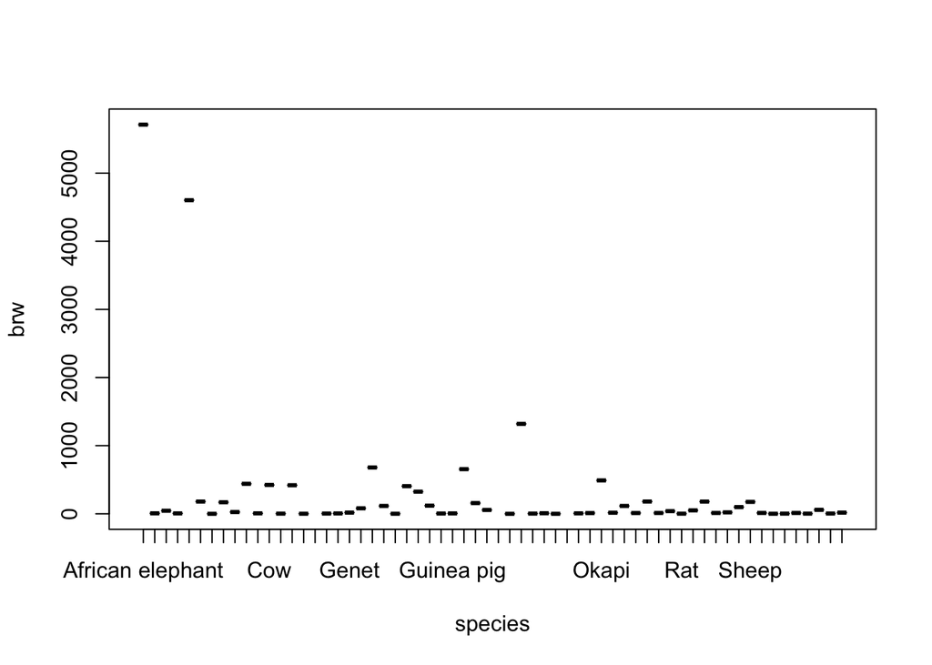

```r
plot(brw ~ species, data = sleepdata2)
```

10. **Some animals have much heavier brains than other animals. Find out the names of the animals that have a brain weight larger than 1 standard deviation above the mean brain weight. Replicate the plot from Question 9 with only these animals and do not plot any information about the other animals.**

To find out which animals have a brain weight larger than 1 standard deviation above the mean brain weight:

```r
sd.brw <- sd(sleepdata2$brw) # standard deviation
mean.brw <- mean(sleepdata2$brw) # mean
which <- sleepdata2$brw > (mean.brw + (1 * sd.brw)) # which are larger?
as.character(sleepdata2$species[which]) # names of the animals with brw > 1000
```

```
## [1] "African elephant" "Asian elephant"   "Man"
```

To plot these animals:

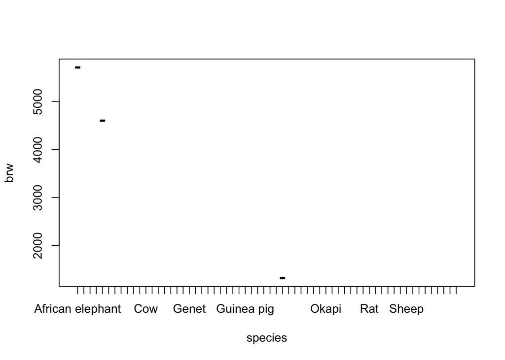

```r
plot(brw ~ species, data = sleepdata2[which, ])
```

The downside is that it still prints all the animals on the x-axis. This is due to the factor labels for `species` being copied to the smaller subset of the data. Plot automatically takes over the labels. For example,

```r
sleepdata2$species[which]
```

```
## [1] African elephant Asian elephant   Man
## 62 Levels: African elephant African giant pouched rat ... Yellow-bellied marmot
```

returns only 3 mammals, but still has 62 factor levels. To get rid of the unused factor levels, we can use function `factor()`:

```r
sleepdata3 <- sleepdata2[which, ]
sleepdata3$species <- factor(sleepdata3$species)
sleepdata3$species
```

```
## [1] African elephant Asian elephant   Man
## Levels: African elephant Asian elephant Man
```

To plot the graph that we wanted:

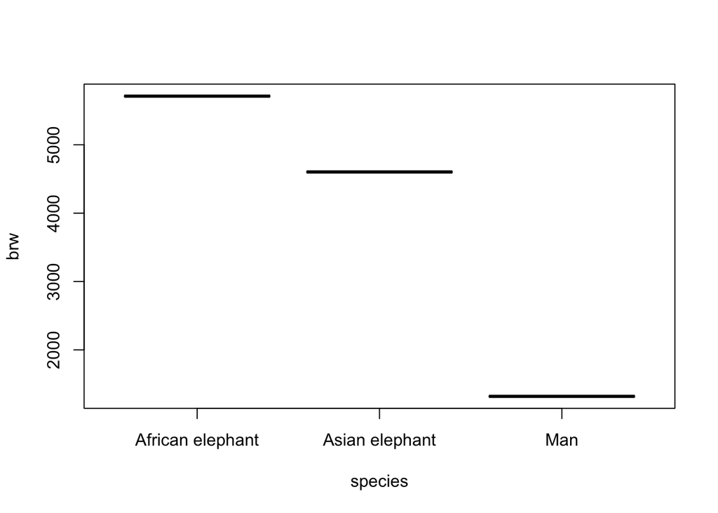

```r
plot(brw ~ species, data = sleepdata3)
```

If your current software-analysis platform is different from `R`, chances are that you prepare your data in the software of your choice. In `R` there are fantastic facilities for importing and exporting data and I would specifically like to pinpoint you to package [`haven`](https://haven.tidyverse.org/index.html) by [Hadley Wickham](http://hadley.nz). It provides wonderful functions to import and export many data types from software such as Stata, SAS and SPSS. For integrating Mplus into `R`, package `MplusAutomation` is essential.

# Useful links

- [`Package haven`](https://haven.tidyverse.org/index.html) for importing/exporting `SPSS`, `SAS` and `STATA` data.

End of exercise